# Influence of climate indicators on tornado ‘outbreak’ environments

*Make a table of the model coefficients.*

```r
DLBSmod_coefs <- summary(DLBS_model)
xtable(DLBSmod_coefs$coefficients, digits = 3)
```

```
## % latex table generated in R 4.0.3 by xtable 1.8-4 package
## % Tue Jun 01 14:28:46 2021
## \begin{table}[ht]
## \centering
## \begin{tabular}{rrrr}
##   \hline
##  & Estimate & Std. Error & t value \\
##   \hline
## (Intercept) & 11.919 & 5.320 & 2.240 \\
##   SSTgradient\_15day & 0.884 & 0.203 & 4.344 \\
##   NAO\_15day & -0.880 & 0.270 & -3.254 \\
##   PNA\_15day & -0.548 & 0.202 & -2.716 \\
##   Lat & 0.344 & 0.060 & 5.721 \\
##   Lon & 0.148 & 0.034 & 4.303 \\
##    \hline
## \end{tabular}
## \end{table}
```

*What are the confidence intervals for the model?*

```r
confint(DLBS_model)
```

```
## Computing profile confidence intervals ...
```

```
##                         2.5 %     97.5 %
## .sig01             2.36439446  6.0841567
## .sigma             5.66718481  6.2449347
## (Intercept)        1.22408595 22.2804380
## SSTgradient_15day  0.47904162  1.3173925
## NAO_15day         -1.40808751 -0.3495230
## PNA_15day         -0.94343878 -0.1540144
## Lat                0.22295506  0.4611042
## Lon                0.08083581  0.2154573
```

*Plot the observed vs Predicted values of DLBS*

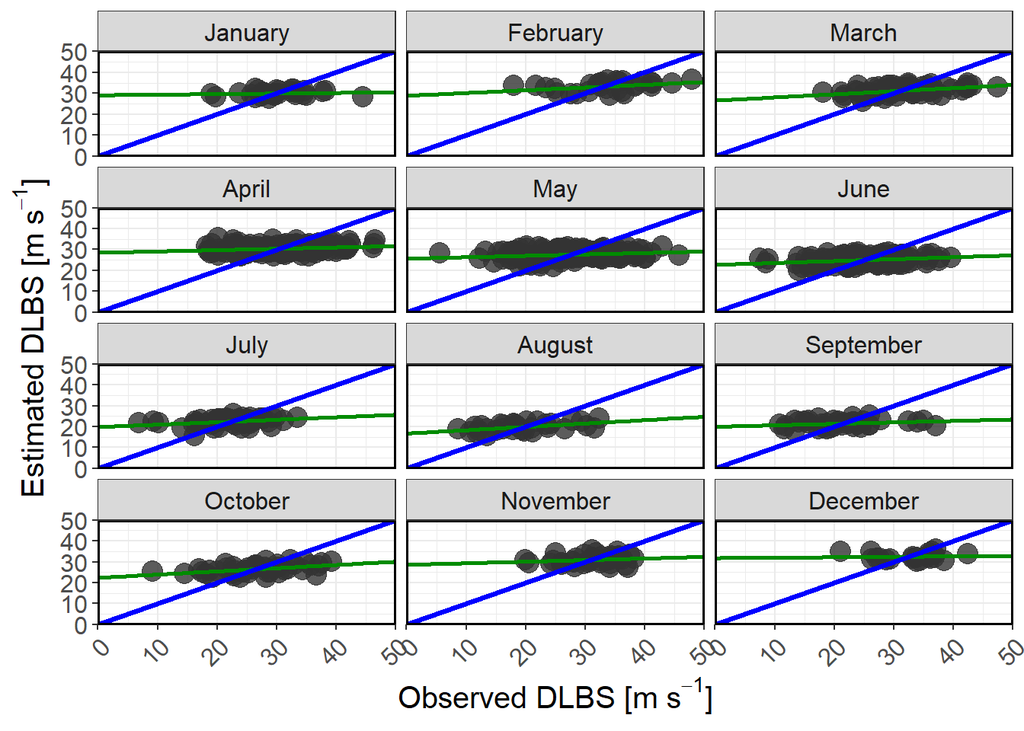

```r
BigDays.sfdfT$Month.name <- factor(BigDays.sfdfT$Month, labels = month.name)

ggplot() +
  geom_point(data = BigDays.sfdfT,
             aes(x = maxBS_deep,
                 y = predDLBS), #col = Month),
             color = "gray20",
             size = 5,
             show.legend = FALSE,
             stroke = 0,
             alpha = 0.8) +
  geom_smooth(method = "lm", data = BigDays.sfdfT,
            aes(x = maxBS_deep,
                 y = predDLBS), color = "green4", se = FALSE, fullrange = TRUE) +
      #scale_colour_continuous(type = "viridis", guide = guide_colorbar(reverse = TRUE)) +
    facet_wrap(~Month.name, ncol = 3, labeller = label_value) +

  geom_abline(slope = 1,
              size = 1.25,
              col = "blue") +
  scale_y_continuous(expand = c(0, 0), limits = c(0, 50)) +
  scale_x_continuous(expand = c(0, 0), limits = c(0, 50)) +
  ylab(expression(paste("Estimated DLBS [m ", s^-1, "]"))) +
      xlab(expression(paste("Observed DLBS [m ", s^-1, "]"))) +
     theme_bw() +
      theme(text = element_text(size=15), strip.background = element_rect(size = 0.5), panel.border=element_rect(colour="black",size=1), panel.background=element_rect(fill="white"), axis.text.x = element_text(angle = 45, hjust = 1))
```

##SLBS Model:

Seasonal Trend:

```r
SLBSByMonth <- BigDays.sfdfT %>%
  group_by(Mo) %>%
  summarize(nC = n(),
            avgSLBS = mean(maxBS_shallow)/nC)
```

[output not shown]

`Make a figure of the Mean SLBS from 1994 to 2020 by month`

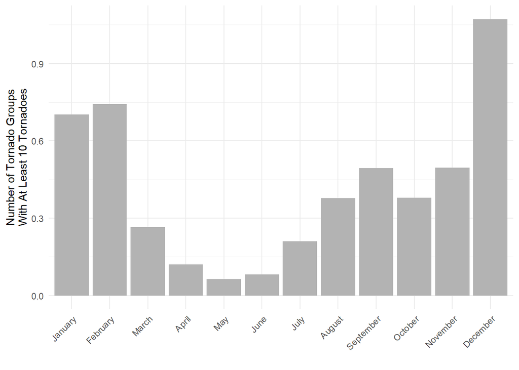

```r
ggplot(SLBSByMonth, aes(x = as.factor(Mo), y = avgSLBS)) +
  geom_bar(stat = "identity", fill = "gray70") +
  scale_x_discrete(labels = month.name) +
  scale_y_continuous(limits = c(0, NA)) +
  ylab("Number of Tornado Groups\nWith At Least 10 Tornadoes") + xlab("") +
  theme_minimal() +
  theme(axis.text.x = element_text(angle = 45, hjust = 1))
```

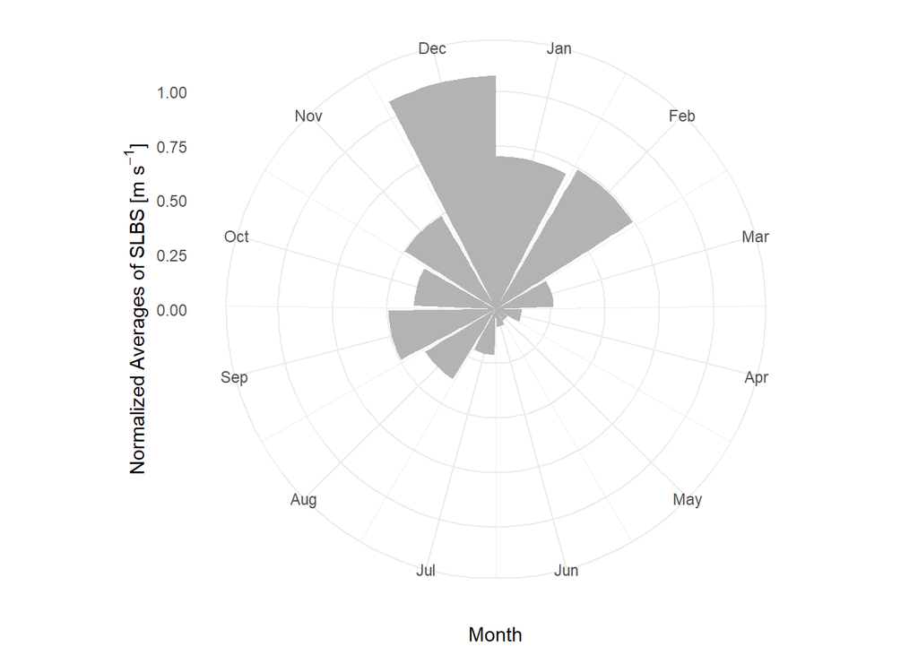

```r
( p2 <- ggplot(SLBSByMonth, aes(x = Mo, y = avgSLBS)) +
  geom_bar(stat = "identity", fill = "gray70") +
 scale_x_continuous(breaks = seq(1, 12, 1), labels = month.abb) +
  scale_y_continuous(limits = c(0, 1.1)) +
  coord_polar(start =0) +
  labs(x = "Month", y = expression(paste("Normalized Averages of SLBS [m ", s^-1, "]"))) +
      #ggtitle("b") +
  theme_minimal() )
```

Diurnal Trend:

```r
SLBSByHour <- BigDays.sfdfT %>%
  group_by(Hour_UTC) %>%
  summarize(nC = n(),
            avgSLBS = mean(maxBS_shallow))
```

[output not shown]

`Make a figure of the total tornadoes from 1994 to 2018 by Hour`

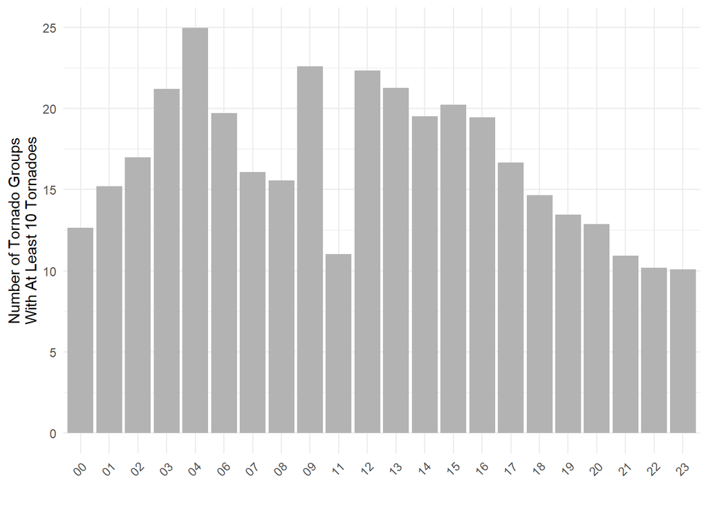

```r
ggplot(SLBSByHour, aes(x = as.factor(Hour_UTC), y = avgSLBS)) +
  geom_bar(stat = "identity", fill = "gray70") +
  #scale_x_discrete(labels = month.name) +
  scale_y_continuous(limits = c(0, NA)) +
  ylab("Number of Tornado Groups\nWith At Least 10 Tornadoes") + xlab("") +
  theme_minimal() +
  theme(axis.text.x = element_text(angle = 45, hjust = 1))
```

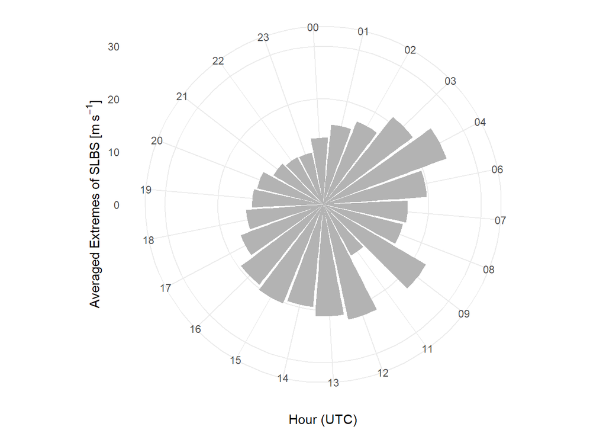

```r
( p3 <- ggplot(SLBSByHour, aes(x = as.factor(Hour_UTC), y = avgSLBS)) +
  geom_bar(stat = "identity", fill = "gray70") +
  #scale_x_discrete(breaks = seq(0, 24, 0.5)) +
  scale_y_continuous(limits = c(0, 30)) +
  coord_polar(start =-0.2) +
  labs(x = "Hour (UTC)", y = expression(paste("Averaged Extremes of SLBS [m ", s^-1, "]"))) +
  theme_minimal() )
```

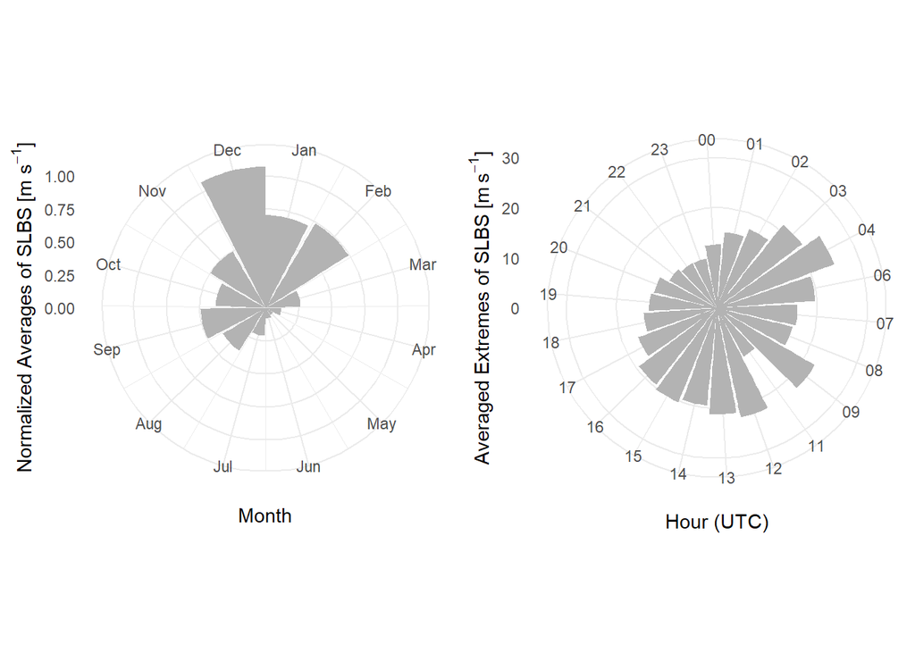

```r
ggarrange(p2, p3)
```

Initial Model:

```r
SLBS_m1 <- lm(maxBS_shallow ~ SSTgradient_15day + avg_Nino3415day + NAO_15day + PNA_15day +  MJO_15day + Lat + Lon + Year, data = BigDays.sfdfT)
summary(DLBS_m1)
```

[output not shown]

```r
SLBSmod_coefs <- summary(SLBS_m1)
xtable(SLBSmod_coefs$coefficients, digits = 3)
```

```
## % latex table generated in R 4.0.3 by xtable 1.8-4 package
## % Tue Jun 01 14:28:52 2021
## \begin{table}[ht]
## \centering
## \begin{tabular}{rrrrr}
##   \hline
##  & Estimate & Std. Error & t value & Pr($>$$|$t$|$) \\
##   \hline
## (Intercept) & -179.441 & 53.999 & -3.323 & 0.001 \\
##   SSTgradient\_15day & 0.469 & 0.107 & 4.391 & 0.000 \\
##   avg\_Nino3415day & -0.859 & 0.256 & -3.356 & 0.001 \\
##   NAO\_15day & -0.386 & 0.261 & -1.480 & 0.139 \\
##   PNA\_15day & -0.656 & 0.199 & -3.289 & 0.001 \\
##   MJO\_15day & 0.305 & 0.387 & 0.790 & 0.430 \\
##   Lat & -0.390 & 0.050 & -7.746 & 0.000 \\
##   Lon & 0.423 & 0.032 & 13.015 & 0.000 \\
##   Year & 0.131 & 0.027 & 4.786 & 0.000 \\
##    \hline
## \end{tabular}
## \end{table}
```

Models:

```r
SLBS_m2 <- lmer(maxBS_shallow ~ SSTgradient_15day + avg_Nino3415day + NAO_15day + PNA_15day +  MJO_15day + Lat + Lon + Year + (1|Month), data = BigDays.sfdfT)
summary(SLBS_m2)
```

```
## Linear mixed model fit by REML ['lmerMod']
## Formula: maxBS_shallow ~ SSTgradient_15day + avg_Nino3415day + NAO_15day +
##     PNA_15day + MJO_15day + Lat + Lon + Year + (1 | Month)
##    Data: BigDays.sfdfT
##
## REML criterion at convergence: 5225.7
##
## Scaled residuals:
##      Min       1Q   Median       3Q      Max
## -2.40310 -0.73496 -0.03549  0.64700  3.09867
##
## Random effects:
##  Groups   Name        Variance Std.Dev.
##  Month    (Intercept)  7.876   2.806
##  Residual             30.208   5.496
## Number of obs: 830, groups:  Month, 12
##
## Fixed effects:
##                     Estimate Std. Error t value
## (Intercept)       -140.24814   52.60875  -2.666
## SSTgradient_15day    0.61329    0.19310   3.176
## avg_Nino3415day     -0.01891    0.29038  -0.065
## NAO_15day           -0.37817    0.25015  -1.512
## PNA_15day           -0.56994    0.19091  -2.985
## MJO_15day            0.23635    0.37391   0.632
## Lat                 -0.15791    0.05538  -2.851
## Lon                  0.38452    0.03184  12.077
## Year                 0.09281    0.02654   3.497
##
## Correlation of Fixed Effects:
##             (Intr) SST_15 a_N341 NAO_15 PNA_15 MJO_15 Lat    Lon
## SSTgrdnt_15 -0.159
## avg_Nn3415d  0.073  0.314
## NAO_15day    0.042  0.058  0.056
## PNA_15day   -0.059  0.073 -0.225  0.110
## MJO_15day   -0.020 -0.011 -0.102  0.043  0.003
## Lat         -0.001  0.117  0.067 -0.056  0.121 -0.020
## Lon          0.094  0.082  0.081 -0.027  0.039  0.025  0.155
## Year        -0.982  0.043 -0.238 -0.053  0.085  0.029 -0.046 -0.062
```

```r
SLBS_m3 <- lmer(maxBS_shallow ~ SSTgradient_15day + NAO_15day + PNA_15day  + Lat + Lon + Year + (1|Month), data = BigDays.sfdfT)
summary(SLBS_m3)
```

```
## Linear mixed model fit by REML ['lmerMod']
## Formula: maxBS_shallow ~ SSTgradient_15day + NAO_15day + PNA_15day + Lat +
##     Lon + Year + (1 | Month)
##    Data: BigDays.sfdfT
##
## REML criterion at convergence: 5225.3
##
## Scaled residuals:
##      Min       1Q   Median       3Q      Max
## -2.38963 -0.72381 -0.02904  0.64638  3.09175
##
## Random effects:
##  Groups   Name        Variance Std.Dev.
##  Month    (Intercept)  7.885   2.808
##  Residual             30.148   5.491
## Number of obs: 830, groups:  Month, 12
##
## Fixed effects:
##                     Estimate Std. Error t value
## (Intercept)       -139.56253   52.41305  -2.663
## SSTgradient_15day    0.61461    0.18314   3.356
## NAO_15day           -0.38504    0.24920  -1.545
## PNA_15day           -0.57029    0.18577  -3.070
## Lat                 -0.15715    0.05520  -2.847
## Lon                  0.38400    0.03169  12.119
## Year                 0.09231    0.02575   3.585
##
## Correlation of Fixed Effects:
##             (Intr) SST_15 NAO_15 PNA_15 Lat    Lon
## SSTgrdnt_15 -0.192
## NAO_15day    0.038  0.041
## PNA_15day   -0.044  0.156  0.127
## Lat         -0.006  0.101 -0.059  0.140
## Lon          0.089  0.059 -0.033  0.060  0.151
## Year        -0.996  0.128 -0.041  0.033 -0.031 -0.045
```

```r
SLBS_m4 <- lmer(maxBS_shallow ~ SSTgradient_15day + PNA_15day  + Lat + Lon + Year + (1|Month), data = BigDays.sfdfT)
summary(SLBS_m4)
```

```
## Linear mixed model fit by REML ['lmerMod']
## Formula: maxBS_shallow ~ SSTgradient_15day + PNA_15day + Lat + Lon + Year +
##     (1 | Month)
##    Data: BigDays.sfdfT
##
## REML criterion at convergence: 5226.8
##
## Scaled residuals:
##      Min       1Q   Median       3Q      Max
## -2.42368 -0.71636 -0.02572  0.64383  3.12588
##
## Random effects:
##  Groups   Name        Variance Std.Dev.
##  Month    (Intercept)  7.832   2.799
##  Residual             30.202   5.496
## Number of obs: 830, groups:  Month, 12
##
## Fixed effects:
##                     Estimate Std. Error t value
## (Intercept)       -136.49123   52.41868  -2.604
## SSTgradient_15day    0.62639    0.18303   3.422
## PNA_15day           -0.53389    0.18442  -2.895
## Lat                 -0.16239    0.05515  -2.945
## Lon                  0.38241    0.03170  12.065
## Year                 0.09070    0.02575   3.522
##
## Correlation of Fixed Effects:
##             (Intr) SST_15 PNA_15 Lat    Lon
## SSTgrdnt_15 -0.194
## PNA_15day   -0.049  0.152
## Lat         -0.004  0.104  0.149
## Lon          0.091  0.061  0.065  0.149
## Year        -0.996  0.130  0.038 -0.033 -0.046
```

```r
AIC(SLBS_m1, SLBS_m2, SLBS_m3, SLBS_m4)
```

```
##         df      AIC
## SLBS_m1 10 5280.687
## SLBS_m2 11 5247.712
## SLBS_m3  9 5243.335
## SLBS_m4  8 5242.779
```

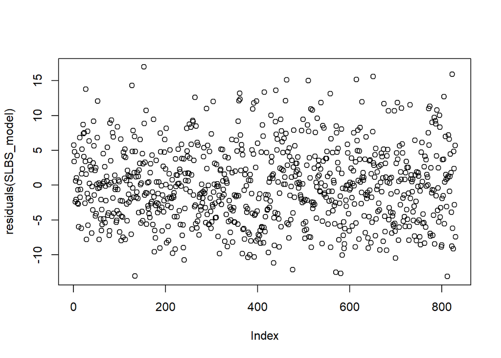

```r
SLBS_model = SLBS_m3
plot(residuals(SLBS_model))
```

There is no relationship between the residuals.

*Make a plot of the standardized residuals for the SLBS model*

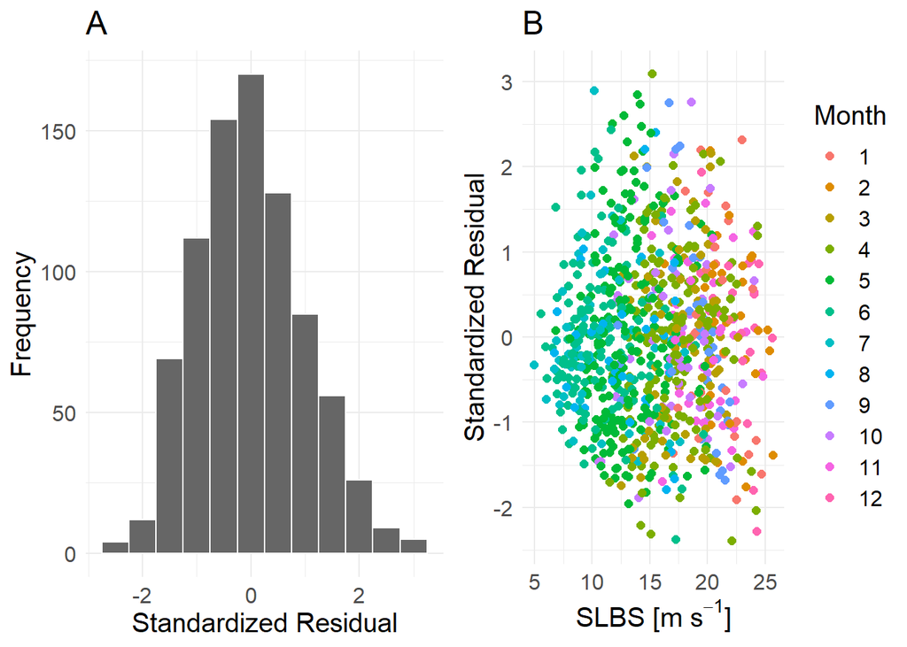

```r
SLBSmod.df <- fortify.merMod(model=SLBS_model, data = nlme::getData(SLBS_model))
SLBSmod.df$predSLBS <- predict(SLBS_model)

pa <- ggplot(SLBSmod.df, aes(x = .scresid)) +
  geom_histogram(binwidth = .5, color = "white", fill = "gray40") +
  xlab("Standardized Residual") + ylab("Frequency") +
  ggtitle("A") +
  theme_minimal() + theme(text = element_text(size=15))

pb <- ggplot(SLBSmod.df, aes(x = .fitted, y = .scresid, color = factor(Mo))) +
         geom_point(size = 2) +
        # scale_x_log10() +
         scale_color_discrete(name = "Month") +
  xlab(expression(paste("SLBS [m ", s^-1, "]"))) + ylab("Standardized Residual") +
  ggtitle("B") +
  theme_minimal() + theme(text = element_text(size=15))
grid.arrange(pa, pb, ncol = 2)
```

*How does the model do compared to the actual values?*

```r
predictSLBS <- predict(SLBS_model)
BigDays.sfdfT$predSLBS <- predictSLBS

cor.test(BigDays.sfdfT$maxBS_shallow, predictSLBS, conf.level = 0.95)
```

```
##
##  Pearson's product-moment correlation
##
## data:  BigDays.sfdfT$maxBS_shallow and predictSLBS
## t = 24.48, df = 828, p-value < 2.2e-16
## alternative hypothesis: true correlation is not equal to 0
## 95 percent confidence interval:
##  0.6066719 0.6857811
## sample estimates:
##       cor
## 0.6479706
```

*Make a table of the model coefficients.*

```r
SLBSmod_coefs <- summary(SLBS_model)
xtable(SLBSmod_coefs$coefficients, digits = 3)
```

```
## % latex table generated in R 4.0.3 by xtable 1.8-4 package
## % Tue Jun 01 14:28:53 2021
## \begin{table}[ht]
## \centering
## \begin{tabular}{rrrr}
##   \hline
##  & Estimate & Std. Error & t value \\
##   \hline
## (Intercept) & -139.563 & 52.413 & -2.663 \\
##   SSTgradient\_15day & 0.615 & 0.183 & 3.356 \\
##   NAO\_15day & -0.385 & 0.249 & -1.545 \\
##   PNA\_15day & -0.570 & 0.186 & -3.070 \\
##   Lat & -0.157 & 0.055 & -2.847 \\
##   Lon & 0.384 & 0.032 & 12.119 \\
##   Year & 0.092 & 0.026 & 3.585 \\
##    \hline
## \end{tabular}
## \end{table}
```

*What are the confidence intervals for the model?*

```r
confint(SLBS_model)
```

```
## Computing profile confidence intervals ...
```

```
##                           2.5 %       97.5 %
## .sig01               1.70980687   4.36616246
## .sigma               5.21670473   5.74813046
## (Intercept)       -242.65556009 -37.61428913
## SSTgradient_15day    0.25969934   0.97219689
## NAO_15day           -0.87167700   0.10281276
## PNA_15day           -0.93674353  -0.20916149
## Lat                 -0.27082945  -0.04983193
## Lon                  0.32242761   0.44653778
## Year                 0.04224729   0.14304919
```

*Plot the observed vs Predicted values of SLBS*

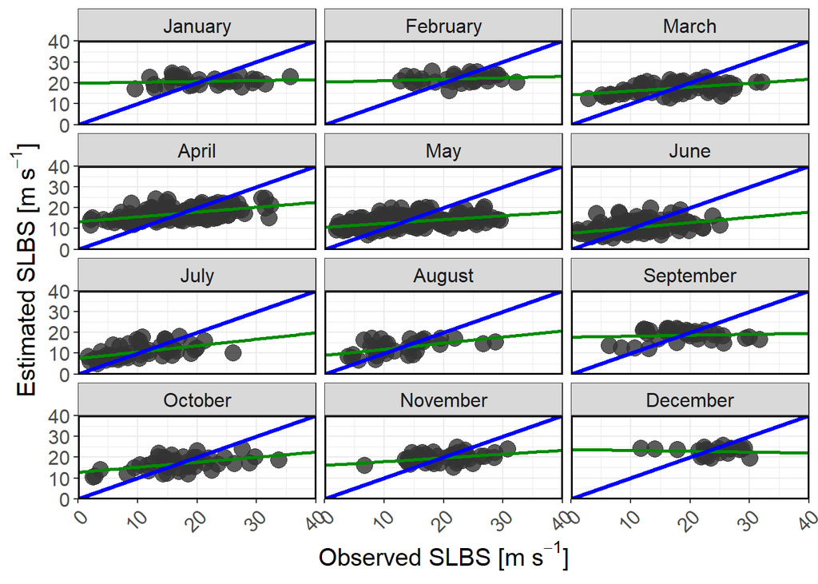

```r
ggplot() +
  geom_point(data = BigDays.sfdfT,
             aes(x = maxBS_shallow,
                 y = predSLBS), #col = Month),
             color = "gray20",
             size = 5,
             show.legend = FALSE,
             stroke = 0,
             alpha = 0.8) +
  geom_smooth(method = "lm", data = BigDays.sfdfT,
            aes(x = maxBS_shallow,
                 y = predSLBS), color = "green4", se = FALSE, fullrange = TRUE) +
      #scale_colour_continuous(type = "viridis", guide = guide_colorbar(reverse = TRUE)) +
    facet_wrap(~Month.name, ncol = 3, labeller = label_value) +

  geom_abline(slope = 1,
              size = 1.25,
              col = "blue") +
  scale_y_continuous(expand = c(0, 0), limits = c(0, 40)) +
  scale_x_continuous(expand = c(0, 0), limits = c(0, 40)) +
  ylab(expression(paste("Estimated SLBS [m ", s^-1, "]"))) +
      xlab(expression(paste("Observed SLBS [m ", s^-1, "]"))) +
     theme_bw() +
      theme(text = element_text(size=15), strip.background = element_rect(size = 0.5), panel.border=element_rect(colour="black",size=1), panel.background=element_rect(fill="white"), axis.text.x = element_text(angle = 45, hjust = 1))
```

##CAPE Model:

Bivariate Relationship:

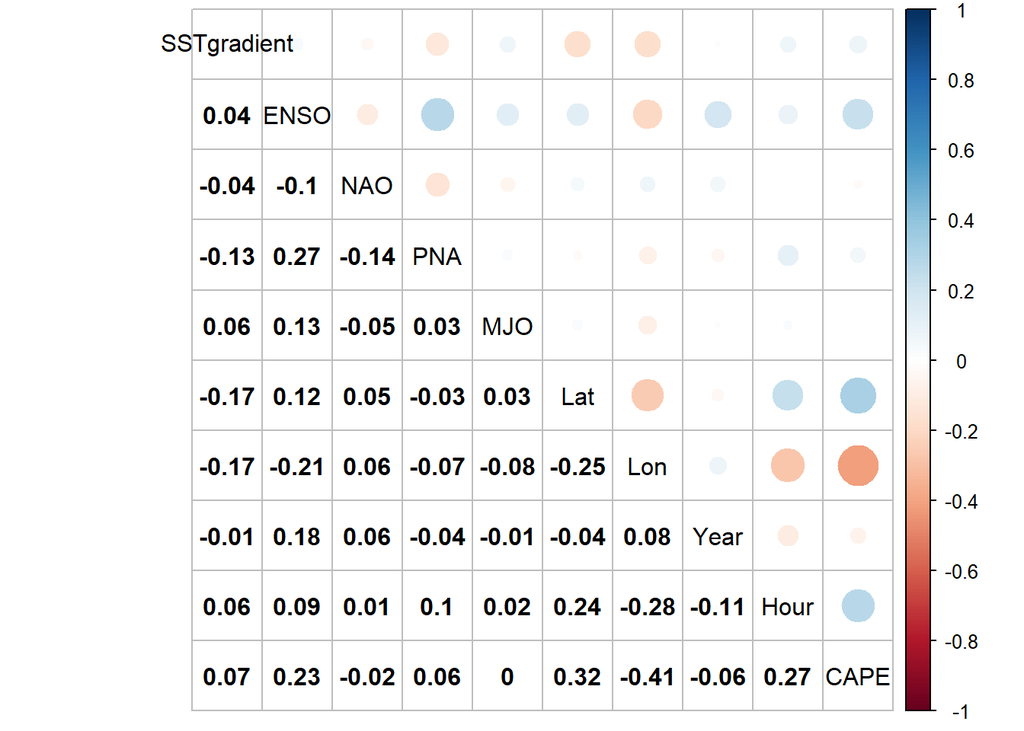

```r
CAPE_env <- data.frame(SSTgradient = BigDays.sfdfT$SSTgradient_15day, ENSO = BigDays.sfdfT$avg_Nino3415day, NAO = BigDays.sfdfT$NAO_15day, PNA = BigDays.sfdfT$PNA_15day, MJO = BigDays.sfdfT$MJO_15day, Lat = BigDays.sfdfT$Lat, Lon = BigDays.sfdfT$Lon, Year = BigDays.sfdfT$Year, Hour = as.numeric(BigDays.sfdfT$Hour_UTC), CAPE = BigDays.sfdfT$maxCAPE)


corrplot.mixed(cor(CAPE_env), tl.col="black", lower.col="black", number.cex = 1, tl.cex = 1)
```

Initial Model:

```r
CAPE_m1 <- lm(maxCAPE ~  SSTgradient_15day + avg_Nino3415day + NAO_15day + PNA_15day +  MJO_15day + Lat + Lon + Year, data = BigDays.sfdfT)
summary(CAPE_m1)
```

```
##
## Call:
## lm(formula = maxCAPE ~ SSTgradient_15day + avg_Nino3415day +
##     NAO_15day + PNA_15day + MJO_15day + Lat + Lon + Year, data = BigDays.sfdfT)
##
## Residuals:
##     Min      1Q  Median      3Q     Max
## -2996.8  -793.7   -66.3   696.8  4148.2
##
## Coefficients:
##                    Estimate Std. Error t value Pr(>|t|)
## (Intercept)        7159.788  11012.823   0.650   0.5158
## SSTgradient_15day    40.102     21.781   1.841   0.0660 .
## avg_Nino3415day     234.472     52.215   4.491 8.12e-06 ***
## NAO_15day            12.558     53.214   0.236   0.8135
## PNA_15day            10.549     40.654   0.259   0.7953
## MJO_15day          -140.325     78.839  -1.780   0.0755 .
## Lat                  73.777     10.277   7.179 1.57e-12 ***
## Lon                 -62.807      6.625  -9.480  < 2e-16 ***
## Year                -10.203      5.562  -1.834   0.0670 .
## ---
## Signif. codes:  0 '***' 0.001 '**' 0.01 '*' 0.05 '.' 0.1 ' ' 1
##
## Residual standard error: 1180 on 821 degrees of freedom
## Multiple R-squared:  0.2463, Adjusted R-squared:  0.239
## F-statistic: 33.54 on 8 and 821 DF,  p-value: < 2.2e-16
```

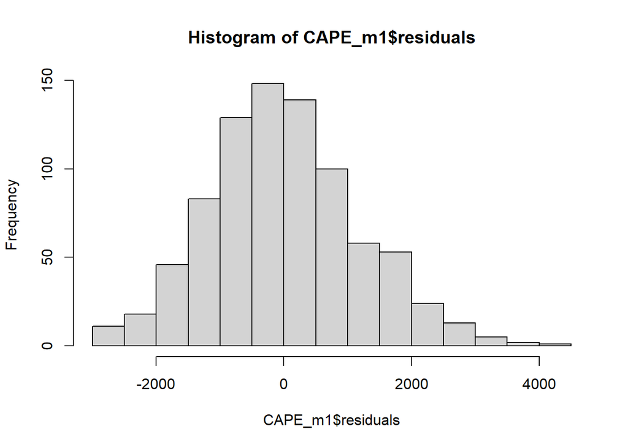

```r
hist(CAPE_m1$residuals)
```

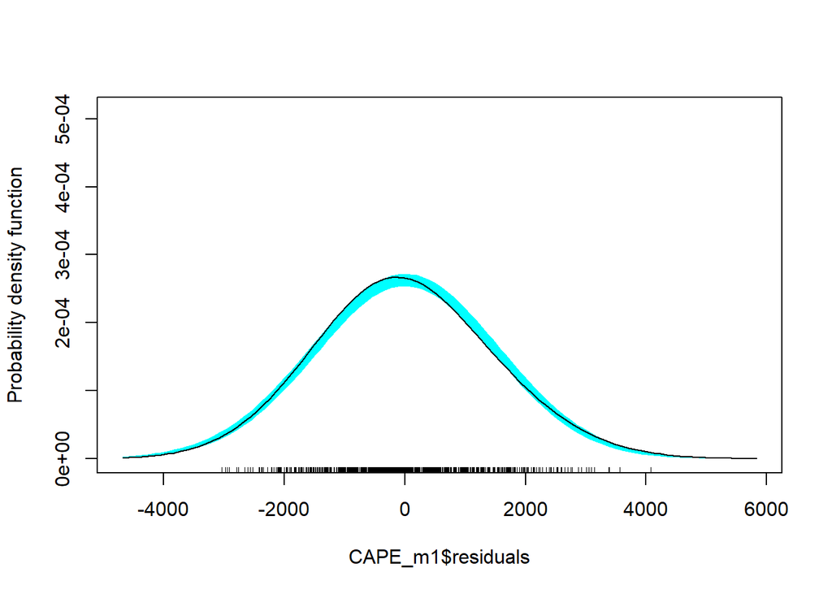

```r
library(sm)
sm.density(CAPE_m1$residuals, model = "Normal")
```

```r
CAPEm1_coefs <- summary(CAPE_m1)
xtable(CAPEm1_coefs$coefficients, digits = 3)
```

```
## % latex table generated in R 4.0.3 by xtable 1.8-4 package
## % Tue Jun 01 14:28:57 2021
## \begin{table}[ht]
## \centering
## \begin{tabular}{rrrrr}
##   \hline
##  & Estimate & Std. Error & t value & Pr($>$$|$t$|$) \\
##   \hline
## (Intercept) & 7159.788 & 11012.823 & 0.650 & 0.516 \\
##   SSTgradient\_15day & 40.102 & 21.781 & 1.841 & 0.066 \\
##   avg\_Nino3415day & 234.472 & 52.215 & 4.491 & 0.000 \\
##   NAO\_15day & 12.558 & 53.214 & 0.236 & 0.814 \\
##   PNA\_15day & 10.549 & 40.654 & 0.259 & 0.795 \\
##   MJO\_15day & -140.325 & 78.839 & -1.780 & 0.075 \\
##   Lat & 73.777 & 10.277 & 7.179 & 0.000 \\
##   Lon & -62.807 & 6.625 & -9.480 & 0.000 \\
##   Year & -10.203 & 5.562 & -1.834 & 0.067 \\
##    \hline
## \end{tabular}
## \end{table}
```

Seasonal Trend:

```r
CAPEByMonth <- BigDays.sfdfT %>%
  group_by(Mo) %>%
  summarize(nC = n(),
            avgCAPE = mean(maxCAPE)/nC)
```

[output not shown]

`Make a figure of the total tornadoes from 1994 to 2018 by month`

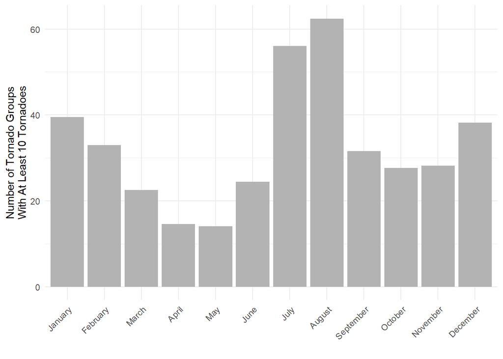

```r
ggplot(CAPEByMonth, aes(x = as.factor(Mo), y = avgCAPE)) +
  geom_bar(stat = "identity", fill = "gray70") +
  scale_x_discrete(labels = month.name) +
  scale_y_continuous(limits = c(0, NA)) +
  ylab("Number of Tornado Groups\nWith At Least 10 Tornadoes") + xlab("") +
  theme_minimal() +
  theme(axis.text.x = element_text(angle = 45, hjust = 1))
```

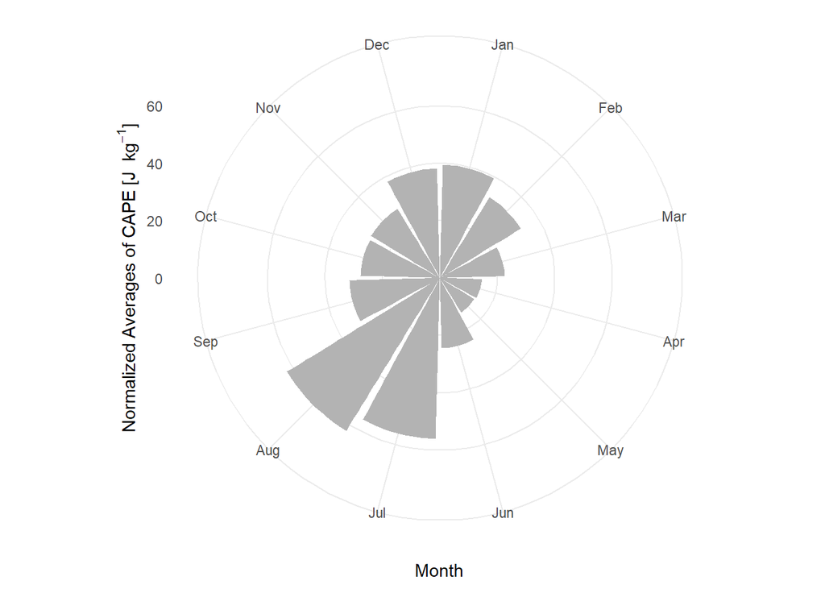

```r
( p4 <- ggplot(CAPEByMonth, aes(x = as.factor(Mo), y = avgCAPE)) +
  geom_bar(stat = "identity", fill = "gray70") +
 scale_x_discrete(breaks = seq(1, 12, 1), labels = month.abb) +
  scale_y_continuous(limits = c(0, 75)) +
  coord_polar(start =0) +
  labs(x = "Month", y = expression(paste("Normalized Averages of CAPE [J  ", kg^-1, "]"))) +
      #ggtitle("c") +
  theme_minimal() )
```

Diurnal Trend:

```r
CAPEByHour <- BigDays.sfdfT %>%
  group_by(Hour_UTC) %>%
  summarize(avgCAPE = mean(maxCAPE))
```

[output not shown]

`Make a figure of the total tornadoes from 1994 to 2018 by Hour`

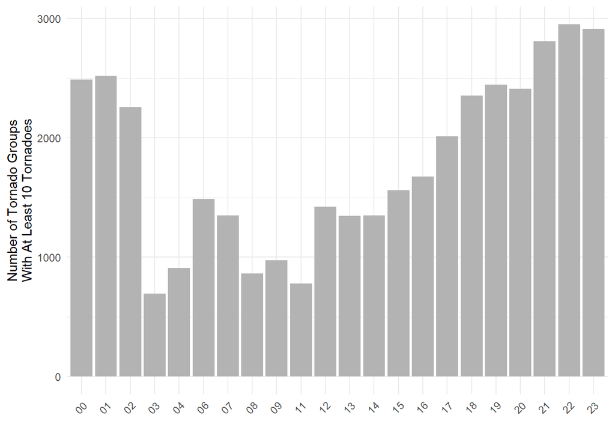

```r
ggplot(CAPEByHour, aes(x = as.factor(Hour_UTC), y = avgCAPE)) +
  geom_bar(stat = "identity", fill = "gray70") +
  #scale_x_discrete(labels = month.name) +
  scale_y_continuous(limits = c(0, NA)) +
  ylab("Number of Tornado Groups\nWith At Least 10 Tornadoes") + xlab("") +
  theme_minimal() +
  theme(axis.text.x = element_text(angle = 45, hjust = 1))
```

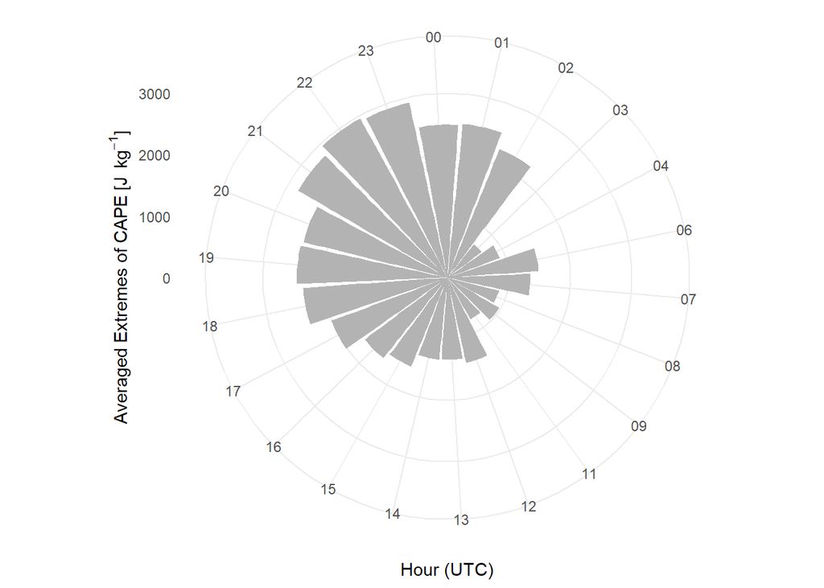

```r
( p5 <- ggplot(CAPEByHour, aes(x = as.factor(Hour_UTC), y = avgCAPE)) +
  geom_bar(stat = "identity", fill = "gray70") +
  #scale_x_discrete(breaks = seq(0, 24, 0.5)) +
  scale_y_continuous(limits = c(0, 3500)) +
  coord_polar(start =-0.2) +
  labs(x = "Hour (UTC)", y = expression(paste("Averaged Extremes of CAPE [J  ", kg^-1, "]"))) +
  theme_minimal() )
```

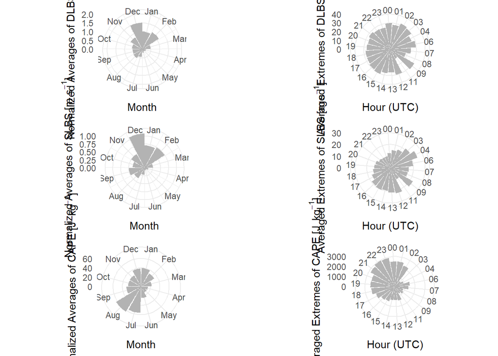

```r
ggarrange(p0, p1, p2, p3, p4, p5, nrow = 3, ncol = 2)
```

Annual Trend:

```r
CAPEByYear <- BigDays.sfdfT %>%
  group_by(Year) %>%
  summarize(avgCAPE = mean(maxCAPE))
```

[output not shown]

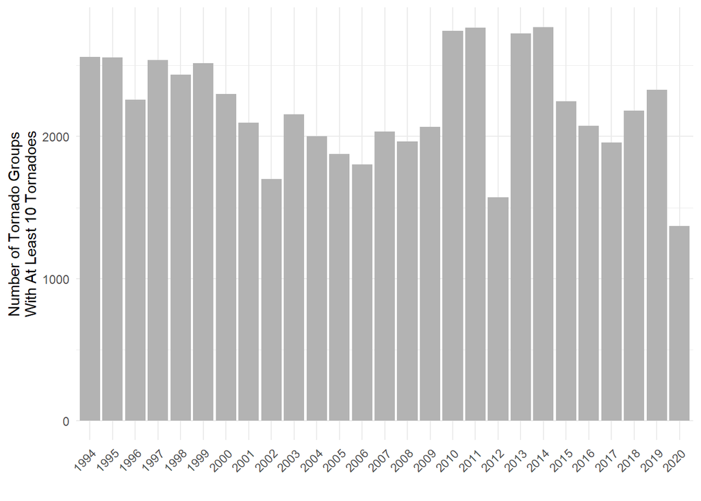

```r
ggplot(CAPEByYear, aes(x = as.factor(Year), y = avgCAPE)) +
  geom_bar(stat = "identity", fill = "gray70") +
  #scale_x_discrete(labels = month.name) +
  scale_y_continuous(limits = c(0, NA)) +
  ylab("Number of Tornado Groups\nWith At Least 10 Tornadoes") + xlab("") +
  theme_minimal() +
  theme(axis.text.x = element_text(angle = 45, hjust = 1))
```

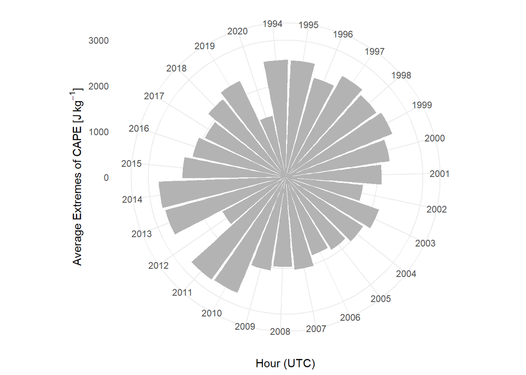

```r
( p6 <- ggplot(CAPEByYear, aes(x = as.factor(Year), y = avgCAPE)) +
  geom_bar(stat = "identity", fill = "gray70") +
  #scale_x_discrete(breaks = seq(0, 24, 0.5)) +
  scale_y_continuous(limits = c(0, 3000)) +
  coord_polar(start =-0.2) +
  labs(x = "Hour (UTC)", y = expression(paste("Average Extremes of CAPE [J ", kg^-1, "]"))) +
  theme_minimal() )
```

##MODELS

```r
CAPE_m2 <- lmer(maxCAPE ~  SSTgradient_15day + avg_Nino3415day + NAO_15day + PNA_15day +  MJO_15day + Lat + Lon + Year + (1|Month) + (1|Hour_UTC), data = BigDays.sfdfT)
summary(CAPE_m2)
```

```
## Linear mixed model fit by REML ['lmerMod']
## Formula:
## maxCAPE ~ SSTgradient_15day + avg_Nino3415day + NAO_15day + PNA_15day +
##     MJO_15day + Lat + Lon + Year + (1 | Month) + (1 | Hour_UTC)
##    Data: BigDays.sfdfT
##
## REML criterion at convergence: 13868.1
##
## Scaled residuals:
##     Min      1Q  Median      3Q     Max
## -2.7137 -0.6491 -0.0685  0.6314  3.2858
##
## Random effects:
##  Groups   Name        Variance Std.Dev.
##  Hour_UTC (Intercept)   97053   311.5
##  Month    (Intercept)  500771   707.7
##  Residual             1087223  1042.7
## Number of obs: 830, groups:  Hour_UTC, 22; Month, 12
##
## Fixed effects:
##                    Estimate Std. Error t value
## (Intercept)       -4216.553  10130.359  -0.416
## SSTgradient_15day   -67.471     38.679  -1.744
## avg_Nino3415day     -46.773     56.114  -0.834
## NAO_15day            -7.945     47.994  -0.166
## PNA_15day           -33.078     36.684  -0.902
## MJO_15day          -107.563     71.552  -1.503
## Lat                  -8.124     11.017  -0.737
## Lon                 -39.854      6.487  -6.144
## Year                  2.632      5.106   0.516
##
## Correlation of Fixed Effects:
##             (Intr) SST_15 a_N341 NAO_15 PNA_15 MJO_15 Lat    Lon
## SSTgrdnt_15 -0.172
## avg_Nn3415d  0.063  0.333
## NAO_15day    0.038  0.069  0.056
## PNA_15day   -0.050  0.067 -0.223  0.114
## MJO_15day   -0.032 -0.001 -0.098  0.042  0.001
## Lat          0.005  0.107  0.070 -0.046  0.125 -0.014
## Lon          0.072  0.082  0.071 -0.032  0.020  0.037  0.058
## Year        -0.981  0.051 -0.232 -0.051  0.075  0.040 -0.058 -0.033
```

```r
CAPE_m3 <- lmer(maxCAPE ~  SSTgradient_15day +  MJO_15day + Lon + (1|Month) + (1|Hour_UTC), data = BigDays.sfdfT)
summary(CAPE_m3)
```

```
## Linear mixed model fit by REML ['lmerMod']
## Formula: maxCAPE ~ SSTgradient_15day + MJO_15day + Lon + (1 | Month) +
##     (1 | Hour_UTC)
##    Data: BigDays.sfdfT
##
## REML criterion at convergence: 13910.5
##
## Scaled residuals:
##     Min      1Q  Median      3Q     Max
## -2.7243 -0.6662 -0.0580  0.6379  3.2971
##
## Random effects:
##  Groups   Name        Variance Std.Dev.
##  Hour_UTC (Intercept)   90064   300.1
##  Month    (Intercept)  442406   665.1
##  Residual             1086410  1042.3
## Number of obs: 830, groups:  Hour_UTC, 22; Month, 12
##
## Fixed effects:
##                   Estimate Std. Error t value
## (Intercept)       -734.536    880.722  -0.834
## SSTgradient_15day  -50.644     35.296  -1.435
## MJO_15day         -115.860     71.036  -1.631
## Lon                -39.315      6.442  -6.103
##
## Correlation of Fixed Effects:
##             (Intr) SST_15 MJO_15
## SSTgrdnt_15 -0.709
## MJO_15day   -0.095  0.032
## Lon          0.612  0.059  0.047
```

```r
CAPE_model <- CAPE_m3
```

*Check the residuals of model of CAPE.*

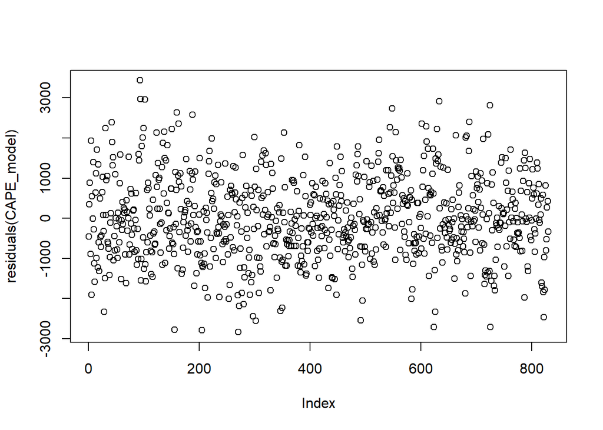

```r
plot(residuals(CAPE_model))
```

*Make a plot of the standardized residuals for the CAPE model*

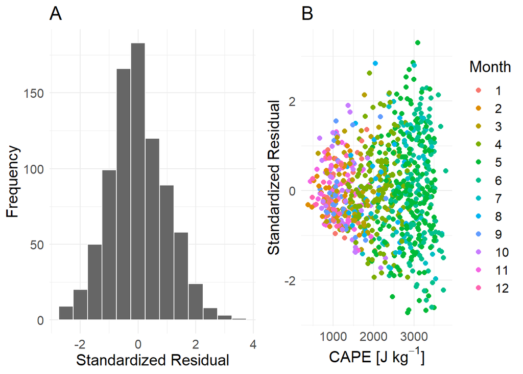

```r
CAPEmod.df <- fortify.merMod(model=CAPE_model, data = nlme::getData(CAPE_model), na.rm = TRUE)
CAPEmod.df$predCAPE <- predict(CAPE_model)

pa <- ggplot(CAPEmod.df, aes(x = .scresid)) +
  geom_histogram(binwidth = .5, color = "white", fill = "gray40") +
  xlab("Standardized Residual") + ylab("Frequency") +
  ggtitle("A") +
  theme_minimal() + theme(text = element_text(size=15))

pb <- ggplot(CAPEmod.df, aes(x = .fitted, y = .scresid, color = factor(Mo))) +
         geom_point(size = 2) +
        # scale_x_log10() +
         scale_color_discrete(name = "Month") +
  xlab(expression(paste("CAPE [J ", kg^-1, "]"))) + ylab("Standardized Residual") +
  ggtitle("B") +
  theme_minimal() + theme(text = element_text(size=15))
grid.arrange(pa, pb, ncol = 2)
```

Conditional standardized residuals from the linear regression model. (A) Histogram and (B) Residuals as a function of predicted values of CAPE. The pattern in B indicates that predictions for larger values of CAPE are less accurate.

*How does the CAPE model do compared to the actual values?*

```r
predictCAPE <- predict(CAPE_model)
BigDays.sfdfT$predCAPE <- predictCAPE

cor.test(BigDays.sfdfT$maxCAPE, predictCAPE, conf.level = 0.95)
```

```
##
##  Pearson's product-moment correlation
##
## data:  BigDays.sfdfT$maxCAPE and predictCAPE
## t = 24.739, df = 828, p-value < 2.2e-16
## alternative hypothesis: true correlation is not equal to 0
## 95 percent confidence interval:
##  0.6109774 0.6893881
## sample estimates:
##      cor
## 0.651922
```

*Make a table of the CAPE model coefficients.*

```r
CAPEmod_coefs <- summary(CAPE_model)
xtable(CAPEmod_coefs$coefficients, digits = 3)
```

```
## % latex table generated in R 4.0.3 by xtable 1.8-4 package
## % Tue Jun 01 14:29:04 2021
## \begin{table}[ht]
## \centering
## \begin{tabular}{rrrr}
##   \hline
##  & Estimate & Std. Error & t value \\
##   \hline
## (Intercept) & -734.536 & 880.722 & -0.834 \\
##   SSTgradient\_15day & -50.644 & 35.296 & -1.435 \\
##   MJO\_15day & -115.860 & 71.036 & -1.631 \\
##   Lon & -39.315 & 6.442 & -6.103 \\
##    \hline
## \end{tabular}
## \end{table}
```

*What are the confidence intervals for the CAPE model?*

```r
confint(CAPE_model)
```

```
## Computing profile confidence intervals ...
```

```
##                         2.5 %     97.5 %
## .sig01              175.64519  503.01338
## .sig02              433.55250 1024.93872
## .sigma              991.49473 1093.64102
## (Intercept)       -2483.91357  994.81704
## SSTgradient_15day  -119.41962   18.32396
## MJO_15day          -255.03848   23.27611
## Lon                 -52.44843  -26.47088
```

*Plot the observed vs Predicted values of CAPE*

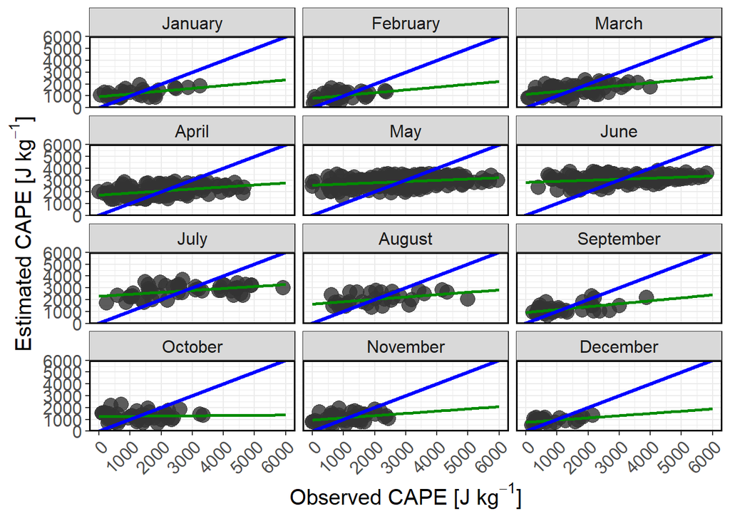

```r
ggplot() +
  geom_point(data = BigDays.sfdfT,
             aes(x = maxCAPE,
                 y = predCAPE), #col = Month),
             color = "gray20",
             size = 5,
             show.legend = FALSE,
             stroke = 0,
             alpha = 0.8) +
  geom_smooth(method = "lm", data = BigDays.sfdfT,
            aes(x = maxCAPE,
                 y = predCAPE), color = "green4", se = FALSE, fullrange = TRUE) +
      #scale_colour_continuous(type = "viridis", guide = guide_colorbar(reverse = TRUE)) +
    facet_wrap(~Month.name, ncol = 3, labeller = label_value) +

  geom_abline(slope = 1,
              size = 1.25,
              col = "blue") +
  scale_y_continuous(expand = c(0,0), limits = c(-5, 6000)) +
  scale_x_continuous(limits = c(-5, 6000), breaks = c(0, 1000, 2000, 3000, 4000, 5000, 6000)) +
  ylab(expression(paste("Estimated CAPE [J ", kg^-1, "]"))) +
      xlab(expression(paste("Observed CAPE [J ", kg^-1, "]"))) +
     theme_bw() +
      theme(text = element_text(size=15), strip.background = element_rect(size = 0.5), panel.border=element_rect(colour="black",size=1), panel.background=element_rect(fill="white"), axis.text.x = element_text(angle = 45, hjust = 1))
```

```r
ggplot() +
  geom_point(data = BigDays.sfdfT,
             aes(x = maxCAPE,
                 y = predCAPE), #col = Month),
             color = "gray20",
             size = 5,
             show.legend = FALSE,
             stroke = 0,
             alpha = 0.8) +
  geom_smooth(method = "lm", data = BigDays.sfdfT,
            aes(x = maxCAPE,
                 y = predCAPE), color = "green4", se = FALSE, fullrange = TRUE) +
      #scale_colour_continuous(type = "viridis", guide = guide_colorbar(reverse = TRUE)) +
    facet_wrap(~Hour_UTC, ncol = 6, labeller = label_value) +

  geom_abline(slope = 1,
              size = 1.25,
              col = "blue") +
  scale_y_continuous(expand = c(0,0), limits = c(-5, 6000)) +
  scale_x_continuous(limits = c(-5, 6000), breaks = c(0, 1000, 2000, 3000, 4000, 5000, 6000)) +
  ylab(expression(paste("Estimated CAPE [J ", kg^-1, "]"))) +
      xlab(expression(paste("Observed CAPE [J ", kg^-1, "]"))) +
     theme_bw() +
      theme(text = element_text(size=15), strip.background = element_rect(size = 0.5), panel.border=element_rect(colour="black",size=1), panel.background=element_rect(fill="white"), axis.text.x = element_text(angle = 45, hjust = 1))
```

[output not shown]

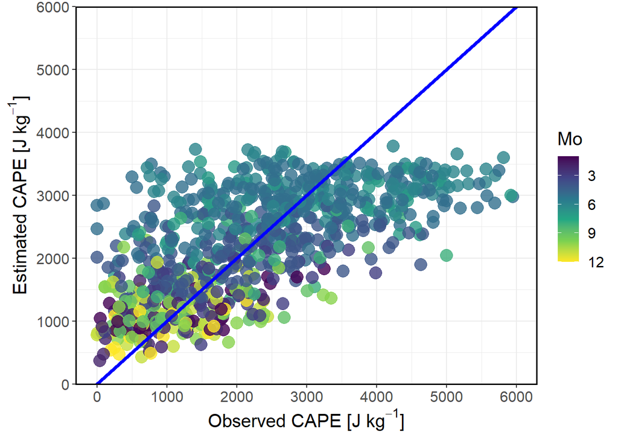

```r
ggplot() +
  geom_point(data = BigDays.sfdfT,
             aes(x = maxCAPE,
                 y = predCAPE, col = Mo),
             size = 5,
             show.legend = TRUE,
             stroke = 0,
             alpha = 0.8) +
      scale_colour_continuous(type = "viridis", guide = guide_colorbar(reverse = TRUE)) +
  geom_abline(slope = 1,
              size = 1.25,
              col = "blue") +
  scale_y_continuous(expand = c(0,0), limits = c(-5, 6000)) +
  scale_x_continuous(limits = c(-5, 6000), breaks = c(0, 1000, 2000, 3000, 4000, 5000, 6000)) +
  ylab(expression(paste("Estimated CAPE [J ", kg^-1, "]"))) +
      xlab(expression(paste("Observed CAPE [J ", kg^-1, "]"))) +
     theme_bw() +
      theme(text = element_text(size=15), strip.background = element_rect(size = 0.5), panel.border=element_rect(colour="black",size=1), panel.background=element_rect(fill="white"))
```

*Why is there such distinction between the predictions and month?*

```r
BigDays.sfdfT %>%
  group_by(Mo) %>%
  summarize(minCAPE = min(maxCAPE),
            maxCAPE = max(maxCAPE),
            difference = maxCAPE - minCAPE)
```

[output not shown]

```
## Simple feature collection with 12 features and 4 fields
## geometry type:  GEOMETRY
## dimension:      XY
## bbox:           xmin: -116.93 ymin: 24.9879 xmax: -70.57 ymax: 49
## geographic CRS: WGS 84
## # A tibble: 12 x 5
##       Mo  minCAPE maxCAPE difference                                    geometry
##    <dbl>    <dbl>   <dbl>      <dbl>                              <GEOMETRY [°]>
##  1     1  50         3250      3200  POLYGON ((-82.57 27.33, -90.82 29.75, -90.~
##  2     2  40         2380      2340  POLYGON ((-82.45 27.17, -82.58718 28.37938~
##  3     3  70         3990      3920  POLYGON ((-100.47 29.13, -101.05 29.53, -1~
##  4     4   0         4660      4660  POLYGON ((-82.52 27.37, -82.7 27.43, -82.7~
##  5     5  -0.0316    6530      6530. POLYGON ((-97.6165 26.1367, -98.8846 27.07~
##  6     6 410         5820      5410  MULTIPOLYGON (((-81.641 25.762, -82.74 27.~
##  7     7 250         5920      5670  MULTIPOLYGON (((-98.23 26.2, -98.32 26.22,~
##  8     8 610         5000      4390  MULTIPOLYGON (((-82.18 26.5, -82.07879 26.~
##  9     9 220         3880      3660  MULTIPOLYGON (((-81.8147 27.565, -81.84481~
## 10    10 110         3350      3240  MULTIPOLYGON (((-81.88 27.22, -82.47 27.75~
## 11    11   0         2440      2440  MULTIPOLYGON (((-98.12 28.33, -98.16817 28~
## 12    12 200         2140      1940  MULTIPOLYGON (((-86.99976 30.988, -86.87 3~
```

**Illustrate the CAPE, SLBS, and DLBS models:**

CAPE

```r
Hours <- seq(1,12,1)

newdata1 = data.frame(SSTgradient_15day = 10, MJO_15day = 1.29,  Lon = -92, Month = 4, Hour_UTC = 18)

newdata2 = data.frame(SSTgradient_15day = 25, MJO_15day = 1.29,  Lon = -72, Month = 4, Hour_UTC = 18)

newdata3 = data.frame(SSTgradient_15day = 18, MJO_15day = 1.29,  Lon = -109, Month = 4, Hour_UTC = 18)

CAPEpred1 <- predict(CAPE_model, newdata = newdata1, allow.new.levels = TRUE, type = "response")
#2364

CAPEpred2 <- predict(CAPE_model, newdata = newdata2, allow.new.levels = TRUE, type = "response")
#818


CAPEpred3 <- predict(CAPE_model, newdata = newdata3, allow.new.levels = TRUE, type = "response")
#2627

CAPEpred1 <- c(10, -92, 2364)
CAPEpred2 <- c(25, -72, 818)
CAPEpred3 <- c(18, -109, 2627)
test <- as.data.frame(rbind(CAPEpred1, CAPEpred2, CAPEpred3))
colnames(test) <- c("SSTgradient_15day", "Lon", "value")
```

Create a prediction grid.

```r
library(reshape2)
```

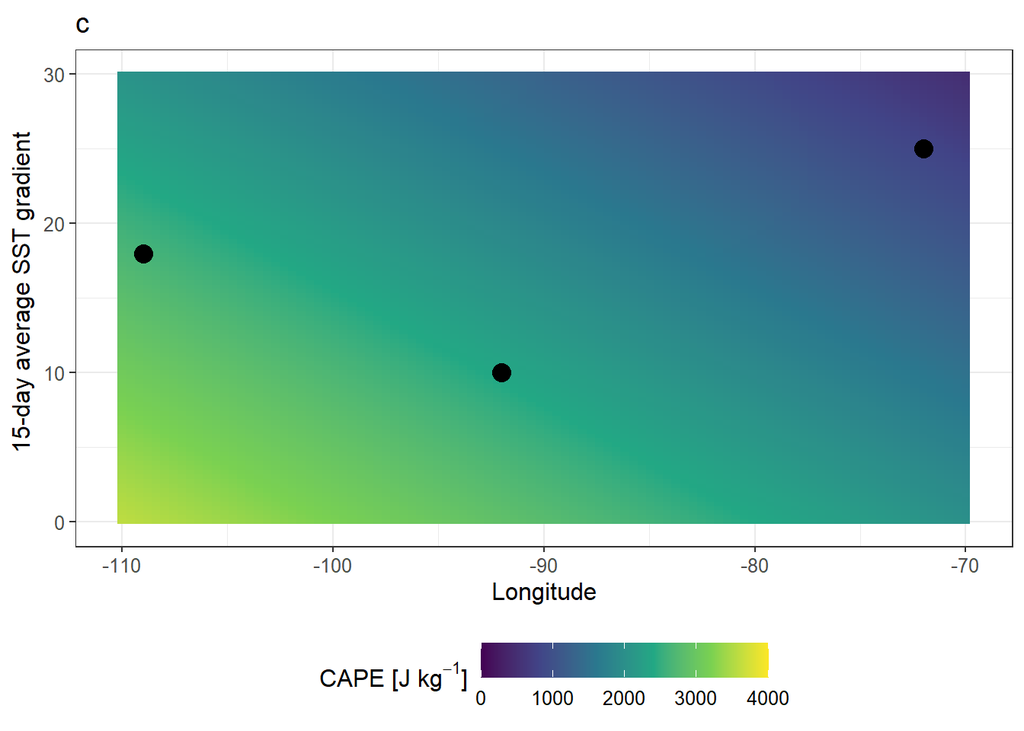

```r
pgrid <- expand.grid(SSTgradient_15day = seq(0, 30, length = 100),
                     MJO_15day = 1.29,
                     Lon = seq(-110, -70, length = 100),
                     Month = 4,
                     Hour_UTC = 18)
pgrid$pre <- predict(CAPE_model, newdata = pgrid, allow.new.levels = TRUE, type = "response")

pgridL = melt(pgrid, id.vars = c("SSTgradient_15day", "Lon"), measure.vars = "pre")

#x<- matrix(pre, nrow = 5001, byrow = FALSE)
e <- c(12, 12.5, 13, 13.5)
 CAPEFIG <- ggplot(pgridL, aes(x = Lon, y = SSTgradient_15day, fill = value)) +
  geom_tile( show.legend = TRUE) +
#geom_contour(aes(z = value), color = "green") +
  #scale_fill_gradient("BuPu")
   #scale_fill_brewer(palette = "BuPu") +
  scale_fill_viridis_c(option = "D", direction = 1, limits = c(0,4000)) +
  theme_bw() +
  theme(text = element_text(size=12), legend.position="bottom", legend.key.width = unit(1, "cm"),
        legend.background = element_rect(size=0.5)) +
     ggtitle("c") +
  xlab(expression(paste("Longitude"))) +
  ylab(expression(paste("15-day average SST gradient"))) +
  labs(fill = expression(paste("CAPE [J ", kg^-1, "]"))) + geom_point(data = test, size = 4)
  CAPEFIG
```

```r
#e <- c(12,  12.5, 13, 13.5)
#ggplot(pgridL, aes(x = maxCAPE2, y = maxBS2, fill = value)) +
 # geom_raster(show.legend = TRUE) +
 # scale_fill_viridis_c(breaks = log(10^e), labels = c(1, 3.2, 10, 32))
```

SLBS

```r
SLBS_model <- SLBS_model

SLBSpred1 <- predict(SLBS_model, newdata = data.frame(SSTgradient_15day = 10, NAO_15day = -0.0197, PNA_15day = -2,  Lat = 37.13, Lon = -92, Year = 2020, Month = 4), type = "response", allow.new.levels = TRUE)
#13

SLBSpred2 <- predict(SLBS_model, newdata = data.frame(SSTgradient_15day = 25, NAO_15day = -0.0197, PNA_15day = -2,  Lat = 37.13, Lon = -72, Year = 2020, Month = 4), type = "response", allow.new.levels = TRUE)
#29.9
SLBSpred3 <- predict(SLBS_model, newdata = data.frame(SSTgradient_15day = 18, NAO_15day = -0.0197, PNA_15day = -2,  Lat = 37.13, Lon = -109, Year = 2020, Month = 4), type = "response", allow.new.levels = TRUE)

#11.4

SLBSpred1 <- c(10, -92, 13)
SLBSpred2 <- c(25, -72, 29.9)
SLBSpred3 <- c(18, -109, 11.4)
test <- as.data.frame(rbind(SLBSpred1, SLBSpred2, SLBSpred3))
colnames(test) <- c("SSTgradient_15day", "Lon", "value")
```

Create a prediction grid.

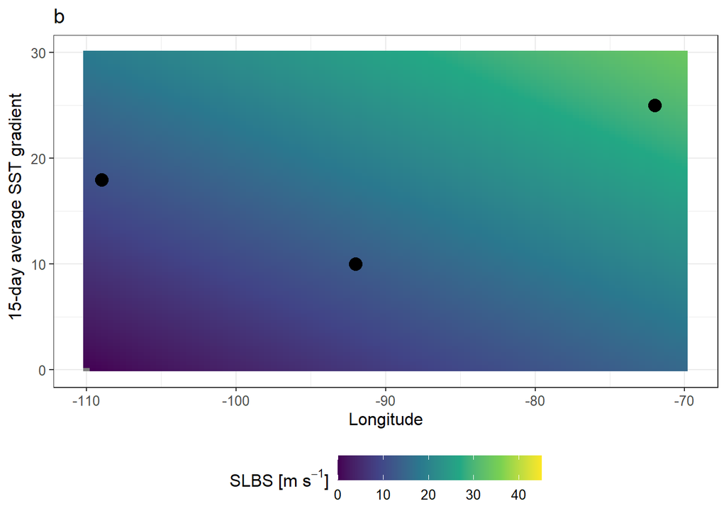

```r
library(reshape2)
pgrid <- expand.grid(SSTgradient_15day = seq(0, 30, length = 100),
                     PNA_15day = -2,
                     NAO_15day = -0.0197,
                     Lat = 37.13,
                     Lon = seq(-110, -70, length = 100),
                     Year = 2020,
                     Month = 4)
pgrid$pre <- predict(SLBS_model, newdata = pgrid, allow.new.levels = TRUE, type = "response")

pgridL = melt(pgrid, id.vars = c("SSTgradient_15day", "Lon"), measure.vars = "pre")

#x<- matrix(pre, nrow = 5001, byrow = FALSE)
e <- c(12, 12.5, 13, 13.5)
 SLBSFIG<- ggplot(pgridL, aes(x = Lon, y = SSTgradient_15day, fill = value)) +
  geom_tile( show.legend = TRUE) +
#geom_contour(aes(z = value), color = "green") +
  #scale_fill_gradient("BuPu")
   #scale_fill_brewer(palette = "BuPu") +
  scale_fill_viridis_c(option = "D", direction = 1, limits = c(0,45)) +
  theme_bw() +
  theme(text = element_text(size=12), legend.position="bottom", legend.key.width = unit(1, "cm"),
        legend.background = element_rect(size=0.5)) +
     ggtitle("b") +
  xlab(expression(paste("Longitude"))) +
  ylab(expression(paste("15-day average SST gradient"))) +
  labs(fill = expression(paste("SLBS [m ", s^-1, "]"))) + geom_point(data = test, size = 4)
 SLBSFIG
```

```r
#e <- c(12,  12.5, 13, 13.5)
#ggplot(pgridL, aes(x = maxCAPE2, y = maxBS2, fill = value)) +
 # geom_raster(show.legend = TRUE) +
 # scale_fill_viridis_c(breaks = log(10^e), labels = c(1, 3.2, 10, 32))
```

DLBS

```r
DLBS_model <- DLBS_model

DLBSpred1 <- predict(DLBS_model, newdata = data.frame(SSTgradient_15day = 10, avg_Nino3415day = 27.3, NAO_15day = -0.0197, PNA_15day = -2,  Lat = 37.13, Lon = -92, Year = 2020, Month = 4), type = "response", allow.new.levels = TRUE)
#21

DLBSpred2 <- predict(DLBS_model, newdata = data.frame(SSTgradient_15day = 25, avg_Nino3415day = 27.3,NAO_15day = -0.0197, PNA_15day = -2,  Lat = 37.13, Lon = -72, Year = 2020, Month = 4), type = "response", allow.new.levels = TRUE)
#37.3
DLBSpred3 <- predict(DLBS_model, newdata = data.frame(SSTgradient_15day = 18, avg_Nino3415day = 27.3,NAO_15day = -0.0197, PNA_15day = -2,  Lat = 37.13, Lon = -109, Year = 2020, Month = 4), type = "response", allow.new.levels = TRUE)

#25.6

DLBSpred1 <- c(10, -92, 21)
DLBSpred2 <- c(25, -72, 37)
DLBSpred3 <- c(18, -109, 25.6)
test <- as.data.frame(rbind(DLBSpred1, DLBSpred2, DLBSpred3))
colnames(test) <- c("SSTgradient_15day", "Lon", "value")
```

Create a prediction grid.

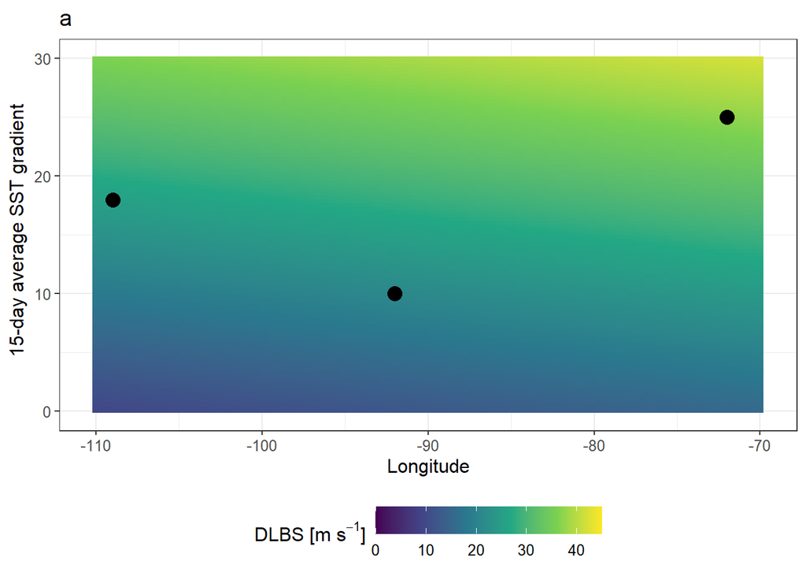

```r
library(reshape2)
pgrid <- expand.grid(SSTgradient_15day = seq(0, 30, length = 100),
                     PNA_15day = -2,
                     avg_Nino3415day = 27.3,
                     NAO_15day = -0.0197,
                     Lat = 37.13,
                     Lon = seq(-110, -70, length = 100),
                     Year = 2020,
                     Month = 4)
pgrid$pre <- predict(DLBS_model, newdata = pgrid, allow.new.levels = TRUE, type = "response")

pgridL = melt(pgrid, id.vars = c("SSTgradient_15day", "Lon"), measure.vars = "pre")

#x<- matrix(pre, nrow = 5001, byrow = FALSE)
e <- c(12, 12.5, 13, 13.5)
DLBSFIG <-  ggplot(pgridL, aes(x = Lon, y = SSTgradient_15day, fill = value)) +
  geom_tile( show.legend = TRUE) +
#geom_contour(aes(z = value), color = "green") +
  #scale_fill_gradient("BuPu")
   #scale_fill_brewer(palette = "BuPu") +
  scale_fill_viridis_c(option = "D", direction = 1, limits = c(0,45)) +
  theme_bw() +
  theme(text = element_text(size=12), legend.position="bottom", legend.key.width = unit(1, "cm"),
        legend.background = element_rect(size=0.5)) +
  ggtitle("a") +
  xlab(expression(paste("Longitude"))) +
  ylab(expression(paste("15-day average SST gradient"))) +
  labs(fill = expression(paste("DLBS [m ", s^-1, "]"))) + geom_point(data = test, size = 4)

DLBSFIG
```

```r
#e <- c(12,  12.5, 13, 13.5)
#ggplot(pgridL, aes(x = maxCAPE2, y = maxBS2, fill = value)) +
 # geom_raster(show.legend = TRUE) +
 # scale_fill_viridis_c(breaks = log(10^e), labels = c(1, 3.2, 10, 32))
```

Combine into a single plot

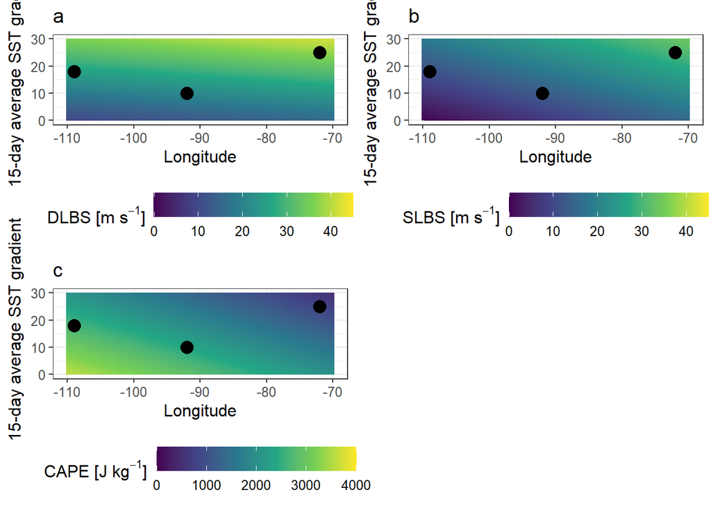

```r
ggarrange(DLBSFIG, SLBSFIG, CAPEFIG, ncol= 2, nrow=2)
```